# Classwork Activity

Sofia Posey

# Instructions (Step by Step)

## Step 1: Create fake data

```
# Creating a small fake dataset
set.seed(2073) # allows for reproducibility

students <- data.frame(
  Name = paste("Student", 1:20),
  StudyHours = round(runif(20, 1, 10), 1),
  Satisfaction = round(rnorm(20, mean = 7, sd = 1.5), 1),
  Major = sample(c("Data Science", "Business Analytics", "Math", "Computer Science"), 20, replace = TRUE)
)

head(students)
```

|  | Name | StudyHours | Satisfaction | Major |
| --- | --- | --- | --- | --- |
| 1 | Student 1 | 6.2 | 9.3 | Math |
| 2 | Student 2 | 4.0 | 6.1 | Computer Science |
| 3 | Student 3 | 8.8 | 5.9 | Computer Science |
| 4 | Student 4 | 4.8 | 6.2 | Data Science |
| 5 | Student 5 | 1.9 | 7.1 | Computer Science |
| 6 | Student 6 | 9.6 | 8.1 | Business Analytics |

## Step 2: Drop a column

```
# Remove the Name column
students$Name <- NULL
```

[output not shown]

[output cut: 10 more lines]

## Step 3: Visualize

```
library(ggplot2)
```

```
ggplot(students, aes(x = Major, y = Satisfaction, fill = Major)) +
  geom_boxplot() +
  labs(
    title = "Student Satisfaction by Major",
    x = "Major",
    y = "Satisfaction (1–10)"
  ) +
  theme_minimal()
```

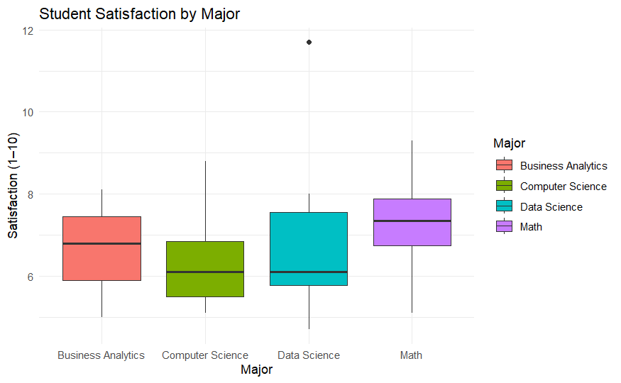

## Step 4: Explain: Write 2–3 sentences each

### Questions:

1. What pattern or difference do you see in the chart?
2. What might explain it?
3. Do you think this chart is accurate?
4. Why? Why not?
5. We see that Computer science major has a more equally distributed data, because the mean seems to be in the midle of the bar, while data science has more data in the lower satisfaction data but the top of the bar is further than the mean this could indicate the existence of outliers. The math major is more concentrated, in other words most students have a similar satisfaction grade. When atlking about pattern we see that the y axis just show the majority of the data between 6 and 8 so overall there is not a big difference in the students opinion.
6. One hypothesis might be that most of the majors are science majors and they might share similar programs classes or proffesors. Also this students are part of an specific group kind of similar in a way that most students might have similar tastes.
7. Because is created data it might not be completly accurate because it doesn’t represent any real group. It doesnt seem very well distributed because it doesn’t show many outliers.
8. I think the create is accurate when representing the previusly stablished data. However this data doesn’t represent any real data. So we can not assume that this could explain a real life scenario. It would be unethical to use it as so.

## Step 5: Questions on Git, GitHub and R Markdown

### Questions:

1. What does git add do?
2. What is the difference between git commit and git push?
3. Why is it useful to use GitHub for your code or data projects?
4. How could version control help when collaborating?
5. What is the difference between a code chunk and regular text in R Markdown?
6. How could R Markdown help you explain your analysis to someone else?